# Part 2

Isaac Moore

May 17, 2016

In this analysis we will look at the “ToothGrowth” dataset which is “The Effect of Vitamin C on Tooth Growth in Guinea Pigs”  
Initialize libraries into R.

```r
library('dplyr')
```

```r
library('ggplot2')
```

### Number 1

**Load the data into R**

```r
data('ToothGrowth')
tooth_growth <- tbl_df(ToothGrowth)
tooth_growth
```

```
## Source: local data frame [60 x 3]
##
##      len   supp  dose
##    (dbl) (fctr) (dbl)
## 1    4.2     VC   0.5
## 2   11.5     VC   0.5
## 3    7.3     VC   0.5
## 4    5.8     VC   0.5
## 5    6.4     VC   0.5
## 6   10.0     VC   0.5
## 7   11.2     VC   0.5
## 8   11.2     VC   0.5
## 9    5.2     VC   0.5
## 10   7.0     VC   0.5
## ..   ...    ...   ...
```

### Number 2

**Exploratory data analysis and summary of the data**  
60 guinea pigs were doses of vitamin C in one of three doeses - 0.5mg, 1mg, or 2mg / day. There were two delivery methods orange juice (coded as ‘OJ’) or asorbic acid(coded as ‘VC’).

```r
oj <- tooth_growth %>% filter(tooth_growth$supp == 'OJ')
summary(oj$len)
```

```
##    Min. 1st Qu.  Median    Mean 3rd Qu.    Max.
##    8.20   15.52   22.70   20.66   25.72   30.90
```

```r
vc <- tooth_growth %>% filter(tooth_growth$supp == 'VC')
summary(vc$len)
```

```
##    Min. 1st Qu.  Median    Mean 3rd Qu.    Max.
##    4.20   11.20   16.50   16.96   23.10   33.90
```

We can see based off of the means of both summaries that OJ yileds greater results.  
Next, Lets take a look at the mean for OJ and VC at each dose.  
*Orange Juice (OJ)*

```r
oj_dose_lens <- tooth_growth %>% filter(tooth_growth$supp == 'OJ') %>%
        group_by(dose) %>%
        summarise(oj_mean_len = mean(len))
oj_dose_lens
```

```
## Source: local data frame [3 x 2]
##
##    dose oj_mean_len
##   (dbl)       (dbl)
## 1   0.5       13.23
## 2   1.0       22.70
## 3   2.0       26.06
```

*Asorbic Acid (VC)*

```r
vc_dose_lens <- tooth_growth %>% filter(tooth_growth$supp == 'VC') %>%
        group_by(dose) %>%
        summarise(vc_mean_len = mean(len))
vc_dose_lens
```

```
## Source: local data frame [3 x 2]
##
##    dose vc_mean_len
##   (dbl)       (dbl)
## 1   0.5        7.98
## 2   1.0       16.77
## 3   2.0       26.14
```

*Plot showing the data*

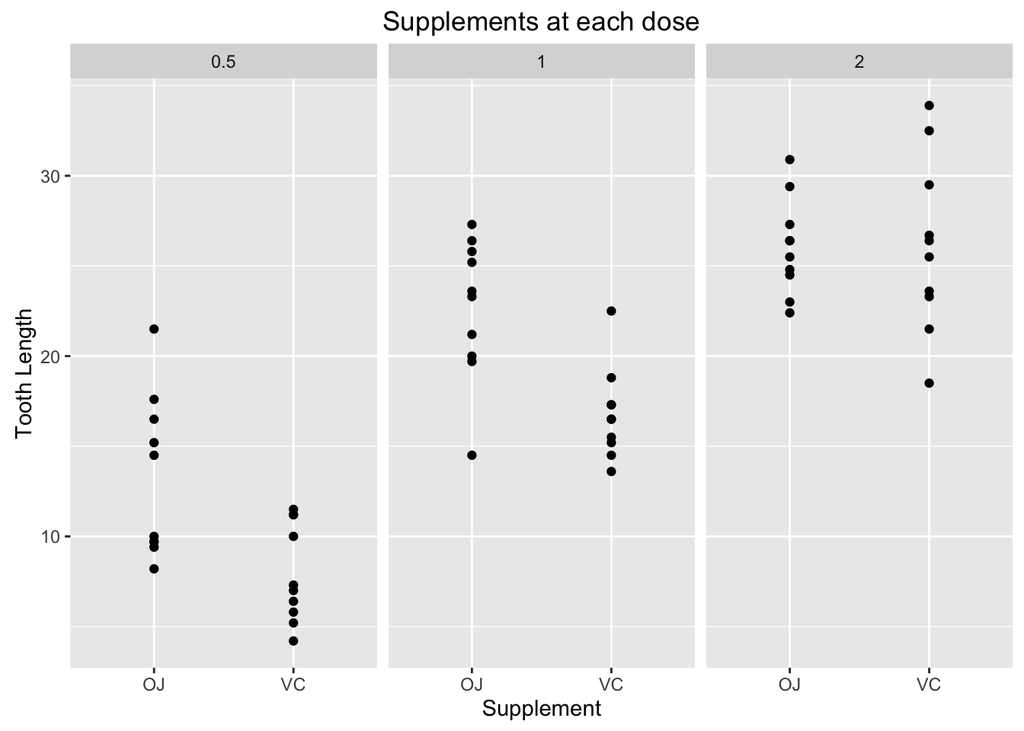

```r
plot <- ggplot(tooth_growth, aes(supp, len))+geom_point()
plot + facet_grid(.~dose)+
        labs(title='Supplements at each dose', y='Tooth Length',x='Supplement')
```

### Number 3

**Welch Two Sample t-test**  
t-test for orange juice and asorbic acid.

```r
t.test(oj$len, vc$len, paired = FALSE, var.equal = FALSE)
```

```
##
##  Welch Two Sample t-test
##
## data:  oj$len and vc$len
## t = 1.9153, df = 55.309, p-value = 0.06063
## alternative hypothesis: true difference in means is not equal to 0
## 95 percent confidence interval:
##  -0.1710156  7.5710156
## sample estimates:
## mean of x mean of y
##  20.66333  16.96333
```

*Testing the disperse 2mg dose.*  
Initalize the data to perform the test.

```r
oj_2 <- filter(tooth_growth, dose == 2.0)
oj_2 <- filter(oj_2, supp == "OJ")
vc_2 <- filter(tooth_growth, dose == 2.0)
vc_2 <- filter(vc_2, supp == "VC")
```

t-test

```r
t.test(oj_2$len, vc_2$len, paired = FALSE, var.equal = FALSE)
```

```
##
##  Welch Two Sample t-test
##
## data:  oj_2$len and vc_2$len
## t = -0.046136, df = 14.04, p-value = 0.9639
## alternative hypothesis: true difference in means is not equal to 0
## 95 percent confidence interval:
##  -3.79807  3.63807
## sample estimates:
## mean of x mean of y
##     26.06     26.14
```